### extracting the topics with LDA (Latent Dirichlet Allocation)

```
library(rio)
library(dplyr)
library(mallet)
library(ggplot2)
library(reshape)
library(wordcloud)

rio：資料I/O相關工具
dplyr：數據操作(Data Manipulation)工具
mallet：主題模型(Topic Modeling)套件
ggplot2：資料視覺化繪圖工具
reshape：數據重塑使用
wordcloud：文字雲套件
```

主題模型( Topic Modeling )也是文字探勘任務之一，這回延用上一則的網站意見信箱資料，假設的情境是如果能從一堆民眾建議事項中歸納出相關的主題，或許有助於決策者了解施政方向和改善重點，提升民眾滿意度。在主題模型中，假設文件是由不同比例的主題所組成，文集中的每個詞在主題中都是一個機率分佈，換言之，在主題中每個詞的機率加總為1。在斷詞的部份，這次使用[中研院CKIP斷詞系統](http://ckipsvr.iis.sinica.edu.tw/)，下面的字串示範CKIP斷詞結果，可發現CKIP除了斷詞，還會加入詞類標記(POS Tagging)

```r
Str <- '迎曦湖停車亂象續'
```

```
## [1] "　迎曦湖(N)　停車(Nv)　亂象(N)　續(ADV)"
```

```
## [1] "迎曦湖 停車 亂象"
```

文集經過前處理、斷詞及詞類過濾後，就能拿來建立主題模型。topicmodels、lda、mallet等都是建立主題模型的套件，以下我採用 mallet 套件方法

```r
# import documents into Mallet format
mallet.instances <- mallet.import(documents$id,
                                  documents$text,
                                  file.path("data", "stsp","myStopword.txt"),
                                  FALSE,
                                  token.regexp="[\\p{L}']+")
```

以三個承辦組室(建管、營建、環安組)的意見信箱為例，假設決策者希望從中歸納出5大主題，每個主題我設定用6個詞來表示

```r
# 主題數
tNum <- 5
# 代表詞數 for each topic
wNum <- 6
# 建立TM trainer
topic.model <- MalletLDA(num.topics = tNum)
topic.model$loadDocuments(mallet.instances)
# Get vocabulary and word frequencies
vocabulary <- topic.model$getVocabulary()
word.freqs <- mallet.word.freqs(topic.model)
# number of iterations
topic.model$train(200)
```

主題-字詞矩陣，前10個字詞示範

```r
# Topic-Words matrix
topic.words.m <- mallet.topic.words(topic.model, smoothed = T, normalized = T)
colnames(topic.words.m) <- vocabulary
topic.words.m[,1:10]
```

```
##              道路       檢查員       工安證       迎曦湖         停車
## [1,] 1.668307e-05 1.668307e-05 1.668307e-05 1.668307e-05 2.337298e-02
## [2,] 3.236240e-02 1.702388e-05 1.702388e-05 1.702388e-05 1.702388e-05
## [3,] 1.614440e-05 1.614440e-05 1.630584e-03 1.614440e-05 1.614440e-05
## [4,] 1.702388e-05 3.421801e-03 1.702388e-05 1.702388e-05 1.702388e-05
## [5,] 1.668307e-05 1.668307e-05 1.668307e-05 2.337298e-02 1.668307e-05
##              亂象         申訴         小時         工安         訓練
## [1,] 1.668307e-05 1.668307e-05 1.668307e-05 6.689912e-03 1.668307e-05
## [2,] 8.528966e-03 1.702388e-05 1.702388e-05 1.702388e-05 1.702388e-05
## [3,] 1.614440e-05 2.584718e-02 1.614440e-05 1.614440e-05 4.859463e-03
## [4,] 1.702388e-05 1.702388e-05 1.702388e-05 1.719412e-03 1.702388e-05
## [5,] 1.668307e-05 1.668307e-05 3.353297e-03 1.668307e-05 1.668307e-05
```

將主題-字詞矩陣依權重排序，5個主題的前6個代表詞如下。決策者可依主題下的代表詞，來了解意見信箱中民眾在意的主題概念，例如：宿舍周邊? 勞資糾紛? 停車問題? 道路交通等…

```
##   Topic.1    停車場      路口  科學園區      機車      停車      路竹
## "weights" "0.05674" "0.02838" "0.02838" "0.02671" "0.02337"  "0.0217"
##   Topic.2      交通      號誌      道路    接駁車      臺南    市政府
## "weights" "0.06811" "0.03577" "0.03236" "0.03236" "0.02045" "0.02045"
##   Topic.3      工作    加班費      台積      申訴      大道    紅綠燈
## "weights" "0.04199" "0.03876" "0.03069" "0.02585" "0.02262" "0.02262"
##   Topic.4      時間      巴士      高雄      巡迴      勞工    勞基法
## "weights"  "0.0596" "0.05279" "0.04598" "0.04428" "0.03577" "0.02896"
##   Topic.5      宿舍      事宜    迎曦湖      電費      夜間      方式
## "weights" "0.21022" "0.02671" "0.02337"  "0.0217"  "0.0167" "0.01336"
```

主題視覺化，以每個主題前100個字詞和權重形成文字雲，幫助了解主題的重點

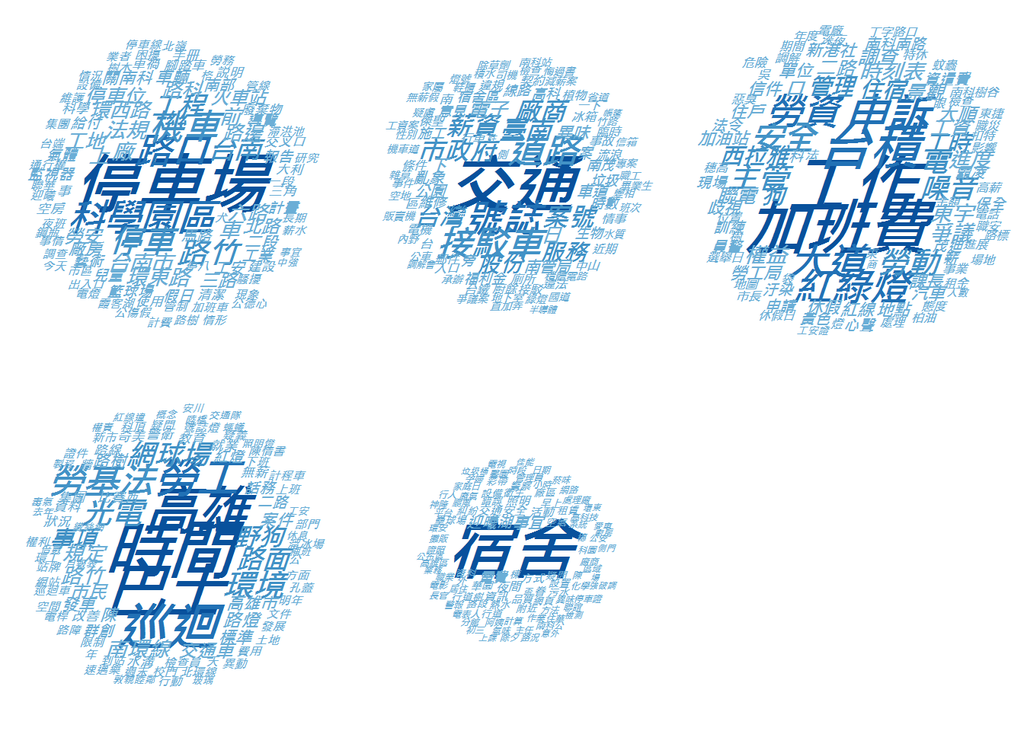

文件-主題矩陣，前10筆文件示範

```r
# Doc-Topics matrix
doc.topics.m <- mallet.doc.topics(topic.model, smoothed = T, normalized = T)
doc.topics.m[1:10,]
```

```
##             [,1]       [,2]      [,3]       [,4]      [,5]
##  [1,] 0.14285714 0.28571429 0.2857143 0.14285714 0.1428571
##  [2,] 0.14285714 0.14285714 0.1428571 0.42857143 0.1428571
##  [3,] 0.28571429 0.14285714 0.2857143 0.14285714 0.1428571
##  [4,] 0.25000000 0.25000000 0.1250000 0.12500000 0.2500000
##  [5,] 0.14285714 0.14285714 0.2857143 0.28571429 0.1428571
##  [6,] 0.18181818 0.09090909 0.2727273 0.09090909 0.3636364
##  [7,] 0.11111111 0.22222222 0.2222222 0.11111111 0.3333333
##  [8,] 0.10000000 0.30000000 0.4000000 0.10000000 0.1000000
##  [9,] 0.09090909 0.09090909 0.5454545 0.09090909 0.1818182
## [10,] 0.11111111 0.22222222 0.4444444 0.11111111 0.1111111
```

有了文件-主題矩陣，接著併入文件所屬組室(dept)的欄位，計算每個組室在各主題的平均權重，如此一來便可以知道主題在各組室的相對比重

```r
doc.topic.means.df
```

```
##   Group.1   Topic.1   Topic.2   Topic.3   Topic.4   Topic.5
## 1  建管組 0.2004783 0.1951018 0.1799334 0.1958827 0.2286039
## 2  營建組 0.2046835 0.2077022 0.1786341 0.2139843 0.1949959
## 3  環安組 0.1948911 0.1951696 0.2277176 0.1971404 0.1850813
```

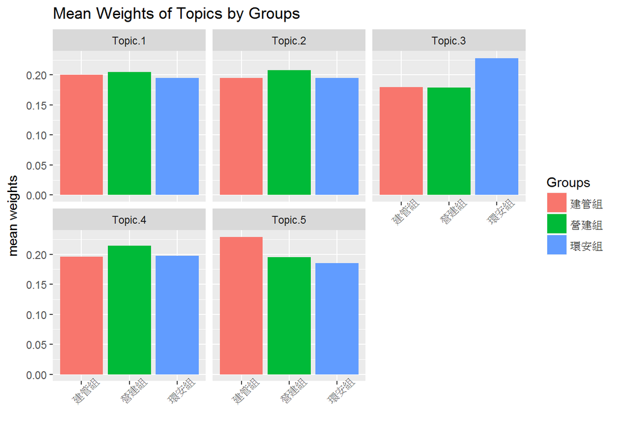

有了主題當橋接，利用以上兩個矩陣可以得到 Document-Term 矩陣，從中可以發現 LDA 有別於傳統模型，例如id為360的文件，其文字內容僅有紅綠燈，在LDA的文件字詞矩陣中也有其他字詞出現的機率值(以機率排序前10字詞為例)

```r
# Doc.Words 機率矩陣(doc-term matrix)
lda.DT.m <- doc.topics.m %*% topic.words.m
documents[360,]
head(sort(lda.DT.m[360,], decreasing = T),10)
```

```
##      id   text
## 360 360 紅綠燈
```

```
##        宿舍        工作      加班費        交通        台積        時間
## 0.060075685 0.012009606 0.011087069 0.009744561 0.008780727 0.008528569
##      停車場        事宜        巴士        申訴
## 0.008119833 0.007881503 0.007555775 0.007396922
```

此外，亦可縮小文件範圍、針對個別組室的意見問題來進行主題偵測。例如組長要知道民眾反應問題前2大主軸為何，透過 LDA 的 Topic Modeling 有助於了解主題樣貌及相關權重

```
## [1] "建管組"
##   Topic.1      宿舍    停車場      停車      電費      機車      事宜
## "weights" "0.20694" "0.02761" "0.02564" "0.02564" "0.02367" "0.01776"
##   Topic.2      交通      巴士      號誌      高雄      巡迴    接駁車
## "weights" "0.04682" "0.03868" "0.03868" "0.03461" "0.03054" "0.02851"
## [1] "營建組"
##   Topic.1      道路      巴士      巡迴      路面      高雄      交通
## "weights"   "0.035" "0.03231" "0.02962" "0.02962" "0.01886" "0.01617"
##   Topic.2    停車場      時間      宿舍    網球場    迎曦湖      路竹
## "weights" "0.05405" "0.04552" "0.04552" "0.02846" "0.02846" "0.02562"
## [1] "環安組"
##   Topic.1    加班費      勞工    勞基法      光電      勞動      野狗
## "weights" "0.03738" "0.03271" "0.02648" "0.02181" "0.01558" "0.01558"
##   Topic.2      工作      申訴      勞資      薪資      交通      台積
## "weights" "0.03833"   "0.025" "0.02167" "0.02001" "0.01834" "0.01834"
```

這次練習運用詞類標記及 mallet 套件方法，相信有助於決策者了解民眾反應事項的主題重點，然而主題擷取及偵測只是 Topic Modeling 應用的一部份，期待後續加入時序的主題追蹤應用

### Lessons Learned:

#### Topic Modeling by mallet.

#### POS (Part-of-Speech) Tagging.

#### LDA (Latent Dirichlet Allocation).